# Machine Learning (M606B) Final Project

Student Name: Seyyed Jalal Tabatabaee  
Student ID: GH1033801  
Github Link: https://github.com/shayantabatabaee/shark-attacks-classification  
Dataset Link: https://www.kaggle.com/datasets/gauravkumar2525/shark-attacks/data  
Shark Research Institue: https://www.sharks.org/

## Introduction

This Jupyter notebook is part of the final project for the machine learning course at Gisma University of Applied Sciences. The project applies traditional machine learning methods to the **Global Shark Attacks Dataset**, which provides a comprehensive record of human-shark interactions worldwide.

The dataset includes key details such as the date, location, type of attack, activity of the person, shark species involved, and whether the attack was fatal. It is a valuable resource for researchers, marine biologists, conservationists, and enthusiasts interested in studying shark behavior, understanding attack patterns, and improving ocean safety.

Given the need for hospitals and first responders to quickly assess whether a shark attack is likely to be fatal, I decided to address this problem using this dataset. By analyzing patterns and key features of past incidents, this project aims to develop a model that can assist in making rapid initial assessments, helping prioritize medical attention and improve emergency response strategies.

This dataset has been imported into Kaggle and is provided by the [Shark Research Institute](http://www.sharks.org/). According to the [original website](https://www.sharkattackfile.net/), the mission of the Global Shark Attack File is to provide current and historical data on shark/human interactions for those who seek accurate and meaningful information and verifiable references.

In the first part of this notebook, I will install the required dependencies and load the data. Next, we will check how clean the dataset is and, if needed, I will apply a cleaning pipeline and best practices to prepare the dataset. In the last part, machine learning methods will be used on the dataset for a classification task, and the best model among them will be saved. Finally, the classification metrics and overall evaluation will be described in detail.

## Install Libraries

```python
!pip install -q kagglehub
!pip install -q pandas
!pip install -q missingno
!pip install -q geopy
!pip install -q tqdm
!pip install -q feature_engine
!pip install -q matplotlib
!pip install -q numpy
!pip install -q scikit-learn
!pip install -q seaborn
!pip install -q imblearn
```

## Import Libraries

```python
import kagglehub
import os
import pandas as pd
import time
from tqdm.notebook import tqdm
import missingno as msno
import re
import math
import sklearn
from geopy.geocoders import Nominatim
from geopy.exc import GeocoderTimedOut
from feature_engine.encoding import RareLabelEncoder
import matplotlib.pyplot as plt
import numpy as np
import seaborn as sns
import imblearn
from collections import Counter
import pickle
```

# Data Preprocessing

## Download Dataset

For downloading the dataset, I used kagglehub library that directly download data from kaggle.

```python
dataset_path = kagglehub.dataset_download("gauravkumar2525/shark-attacks")
print("Path to dataset files:", dataset_path)
print("Dataset Filename:", os.listdir(dataset_path)[0])
```

```
Path to dataset files: /Users/shayantabatabaee/.cache/kagglehub/datasets/gauravkumar2525/shark-attacks/versions/1
Dataset Filename: global_shark_attacks.csv
```

## Load Dataset

```python
data = pd.read_csv(os.path.join(dataset_path, os.listdir(dataset_path)[0]))
print("Data loaded successfully!")
print(f"Dataset shape: {data.shape}")
data.head()
```

```
Data loaded successfully!
Dataset shape: (6890, 13)
```

|  | date | year | type | country | area | location | activity | name | sex | age | fatal_y_n | time | species |
| --- | --- | --- | --- | --- | --- | --- | --- | --- | --- | --- | --- | --- | --- |
| 0 | 2023-05-13 | 2023.0 | Unprovoked | AUSTRALIA | South Australia | Elliston | Surfing | Simon Baccanello | M | 46 | Y | 10h10 | White shark |
| 1 | 2023-04-29 | 2023.0 | Unprovoked | AUSTRALIA | Western Australia | Yallingup, Busselton | Swimming | male | M | NaN | N | 11h20 | 1m shark |
| 2 | 2022-10-07 | 2022.0 | Unprovoked | AUSTRALIA | Western Australia | Port Hedland | Spearfishing | Robbie Peck | M | 38 | N | 11h30 | Bull shark |
| 3 | 2021-10-04 | 2021.0 | Unprovoked | USA | Florida | Fort Pierce State Park, St. Lucie County | Surfing | Truman Van Patrick | M | 25.0 | N | NaN | NaN |
| 4 | 2021-10-03 | 2021.0 | Unprovoked | USA | Florida | Jensen Beach, Martin County | Swimming | male | M | NaN | N | 12h00 | NaN |

## Clean Dataset

In this section, I will first check if there are any missing values. I will also look at the data type for each column. If the data type is numerical and there are no missing values, we’re ready to move forward, but later we’ll need to check the distribution of the data to see if there are too many zeros. If the data type is object and categorical, we’ll check each value in the column to ensure they make sense. The most helpful library for getting insights about all features at once is *missingno*. Let's first check our targets i.e. *fatal_y_n* column and remove if there is nonsense values. Next I will check the NaN and empty values for all features using this library.

```python
data['fatal_y_n'].value_counts()
```

```
fatal_y_n
N          4804
Y          1447
UNKNOWN     631
F             3
y             1
Y x 2         1
n             1
2017.0        1
Nq            1
Name: count, dtype: int64
```

As we can see, there are 631 UNKNOWN values which we can remove the rows. Also for example there are 3 F and 1 y which we can combine with N and Y targets.

```python
# Remove UNKNOWN rows
data = data[data['fatal_y_n'] != 'UNKNOWN']
# Replace other values
data['fatal_y_n'] = data['fatal_y_n'].replace({
    'F': 'N',
    'y': 'Y',
    'Y x 2': 'Y'
})
# Keep only valid values (N and Y)
data = data[data['fatal_y_n'].isin(['N', 'Y'])]
```

```python
data['fatal_y_n'].value_counts()
```

```
fatal_y_n
N    4807
Y    1449
Name: count, dtype: int64
```

Now our target column is clean, Let's check the other columns as well.

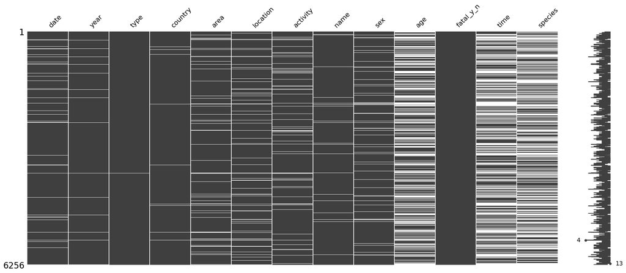

```python
%matplotlib inline
msno.matrix(data)
```

As we can see in the images above, the white sections show that there are many null values in our dataset. For example, these columns have fewer null values: ['date', 'year', 'type', 'country', 'name', 'fatal_y_n']. But on the other hand, the ['age', 'time', 'species'] columns have a lot of null values. Let's check the datatypes of each column.

```python
print(data.info())
```

[output not shown]

The only column that is numerical is *year*, so we can use some feature imputation techniques for this column like replace null values with mean, median or a fixed value. For other columns let's check the values to get better insights.

```python
for column in data.columns:
  if data[column].dtype == type(object):
    print(f"{column}: {data[column].unique()}")
```

```
date: ['2023-05-13' '2023-04-29' '2022-10-07' ... '1828-01-01' '1792-09-12'
 '1703-03-26']
type: ['Unprovoked' 'Provoked' 'Invalid' 'Watercraft' 'Sea Disaster'
 'Questionable' nan 'Boat' 'Unverified' '?' 'Under investigation']
country: ['AUSTRALIA' 'USA' 'JAMAICA' 'NEW ZEALAND' 'PAPUA NEW GUINEA'
 'FRENCH POLYNESIA' 'CHINA' 'SOUTH AFRICA' 'BAHAMAS' 'NEW CALEDONIA'
 'REUNION' 'PALESTINIAN TERRITORIES' 'BELIZE' 'PHILIPPINES' 'MOZAMBIQUE'
 'KENYA' 'BRAZIL' 'FIJI' 'TANZANIA' 'ENGLAND' 'THAILAND' 'SOUTH KOREA'
 'MAURITIUS' 'ITALY' 'MEXICO' 'MARSHALL ISLANDS' 'SPAIN' 'TAIWAN' 'TURKEY'
 'SENEGAL' 'AMERICAN SAMOA' 'PACIFIC OCEAN' 'INDIAN OCEAN' 'NEW GUINEA'
 'SOLOMON ISLANDS' 'GREECE' 'COSTA RICA' 'INDONESIA' 'CUBA' 'GEORGIA'
 'SIERRA LEONE' 'Coast of AFRICA' 'INDIA' 'TOBAGO' 'EGYPT' 'SAMOA'
 'DOMINICAN REPUBLIC' 'MADAGASCAR' 'MALAYSIA' 'GULF OF ADEN' 'SOMALIA'
 'CHILE' nan 'SINGAPORE' 'BRITISH WEST INDIES' 'NORTH ATLANTIC OCEAN'
 'SRI LANKA' 'OKINAWA' 'SOUTH PACIFIC OCEAN' 'SOUTH ATLANTIC OCEAN'
 'CARIBBEAN SEA' 'MONTENEGRO' 'YEMEN' 'VIETNAM' 'COOK ISLANDS'
 'WEST INDIES' 'TURKS and CaICOS' 'Sierra Leone' 'TONGA' 'VANUATU' 'IRAN'
 'HONG KONG' 'NEW BRITAIN' 'SOLOMON ISLANDS / VANUATU' 'PANAMA' 'GUYANA'
 'ATLANTIC OCEAN' 'INDIAN OCEAN?' 'CANADA' 'MEDITERRANEAN SEA' 'BURMA'
 'ST KITTS / NEVIS' 'MALDIVES' 'ECUADOR' 'JAPAN' 'VENEZUELA'
 'PERSIAN GULF' 'THE BALKANS' 'NICARAGUA' 'BARBADOS' 'SAN DOMINGO'
 'CROATIA' 'FRANCE' 'LEBANON' 'RED SEA?' 'IRAQ' 'NIGERIA' 'WESTERN SAMOA'
 'SCOTLAND' 'CEYLON' 'PERU' 'SUDAN' 'SAUDI ARABIA' 'REUNION ISLAND'
 'NORWAY' 'GRENADA' 'FEDERATED STATES OF MICRONESIA'
 'NETHERLANDS ANTILLES' 'PORTUGAL' 'HONDURAS' 'CYPRUS' 'HAITI' 'ALGERIA'
 'BERMUDA' 'UNITED KINGDOM' 'MAYOTTE' 'COLUMBIA' 'LIBYA' 'South Africa'
 'MID ATLANTIC OCEAN' 'MALDIVE ISLANDS' 'MARTINIQUE'
 'SOUTHWEST PACIFIC OCEAN' 'KUWAIT' 'Fiji' 'PUERTO RICO' 'TURKS & CAICOS'
 'ISRAEL' 'BRITISH ISLES' 'MALTA' 'LIBERIA' 'NAMIBIA' 'ASIA?' 'RUSSIA'
 'RED SEA' 'PALAU' 'ADMIRALTY ISLANDS' 'ANDAMAN / NICOBAR ISLANDAS'
 'SLOVENIA' 'URUGUAY' 'NORTH PACIFIC OCEAN' 'MeXICO' 'BANGLADESH'
 'JOHNSTON ISLAND' 'NORTHERN MARIANA ISLANDS' 'GREENLAND' 'KIRIBATI'
 'IRELAND' 'AZORES' 'ARGENTINA' 'AFRICA' 'ST MARTIN' 'TRINIDAD & TOBAGO'
 'SEYCHELLES' 'OCEAN' 'UNITED ARAB EMIRATES (UAE)' 'MICRONESIA' 'ICELAND'
 'TUVALU' 'EQUATORIAL GUINEA / CAMEROON' 'Between PORTUGAL & INDIA'
 'DJIBOUTI' 'SUDAN?' 'ANDAMAN ISLANDS' 'CEYLON (SRI LANKA)' 'JORDAN'
 'MONACO' 'TUNISIA' 'GHANA' 'EGYPT / ISRAEL' 'IRAN / IRAQ' 'JAVA'
 'ST HELENA, British overseas territory' 'ST. MAARTIN' 'NORTH SEA'
 'BRITISH NEW GUINEA' 'British Overseas Territory' 'GUAM' 'EL SALVADOR'
 'RED SEA / INDIAN OCEAN' 'ANGOLA' 'CENTRAL PACIFIC' 'Australia'
```

[output cut: 307 more lines]

```
 '1500.0' 'Early  morning' '08h40' '9h00' 'Just before 11h00'
 '17h00 or 17h40' '09h00 -10h00' '20h45 (Sunset)' '15h49' '18h25' '11h51'
 '13h35' '10h00 or 14h00' '19h10' '07h53' '13h19' '17h34' '09h30 / 10h00'
 '17h51' '07h00 - 08h00' '14h21' '>08h00' '13h23' 'Just after 12h00'
 '08h35' '08h55' '07h07' '1415.0' '06h55' '10h16' '10h00 -- 11h00' '16h14'
 '11h53' 'Before 10h00' '10h43' '05h45' 'Shortly before 13h00'
 'After Dusk' '2 hours after Opperman' '01h30' '19h00-20h00' '11h46'
 '13h42' '18h15-18h30' '0830' '17h11' '14h16' 'Prior to 10h37' 'Daybreak'
 '0500' '11h06' '18h12' 'Nightfall' '10h30 or 13h30' 'Late Afternoon'
 '09h36' '14h33' '10h45-11h15' '16h12' '06h10' 'Shortly after midnight'
 '<07h30' 'Before daybreak' '06h00 -- 07h00' '14h09' '11h24' '08h56'
 '06j00' '12h45 / 13h45' 'Ship aban-doned at 03h10' '19h55' '`17h00'
 '08h48' '16h26' '30 minutes after 1992.07.08.a' '17h00-18h00']
species: ['White shark' '1m shark' 'Bull shark' ... '100-lb shark'
 "Blue shark, 8' [2.4 m], 500-lb" "Said to be a 7.6 m [25'] shark"]
```

As we can see in our features, the *date* and *year* columns represent the same information and are duplicates, so for the first step, we remove the *date* column and replace null values in the *year* column with the average of the years. This dataset is messy, and we need to take a specific action for each column.

```python
if 'date' in data.columns:
    data = data.drop(columns=['date'])
data['year'] = data['year'].fillna(round(data['year'].mean()))
```

Now for the next step let's focus on *type* column.

```python
data['type'].value_counts()
```

```
type
Unprovoked             4991
Provoked                623
Watercraft              340
Sea Disaster            237
Invalid                  25
Questionable             16
Boat                      7
Unverified                1
?                         1
Under investigation       1
Name: count, dtype: int64
```

For the type column we can see there is ? value. So first we change to None and next we will drop all of None values.

```python
data['type'] = data['type'].replace('?', None)
data = data.dropna(subset=['type'])
```

Now, for the *country, area, location* columns, we first remove the location column because, after checking its values, it seems mostly nonsensical and useless. Next, we remove any row where both country and area are None at the same time. Later, I will convert the combination of area and country into latitude and longitude since that will give us more useful information.

```python
if 'location' in data.columns:
    data = data.drop(columns=['location'])
data = data.dropna(subset=['area', 'country'], how='all')
```

```python
geolocator = Nominatim(user_agent="geo_converter")
def get_latitude_longitude(area, country):
    try:
        location = geolocator.geocode(f"{area}, {country}")
        time.sleep(0.75)
        if location:
            return pd.Series([location.latitude, location.longitude])
    except GeocoderTimedOut:
        return pd.Series([None, None])
    return pd.Series([None, None])

tqdm.pandas()
data[['latitude', 'longitude']] = data.progress_apply(lambda x: get_latitude_longitude(x['area'], x['country']), axis=1)
```

As we can see, the above method takes almost two hours to complete. In order not to wait, I commited the outcome alongside the jupyter notebook into Github repository. The dataframe can be loaded into data using the following command.

```python
data = pd.read_csv('shark_attacks_lat_long.csv',index_col=0)
```

```python
if 'area' in data.columns:
     data = data.drop(columns=['area'])
if 'country' in data.columns:
     data = data.drop(columns=['country'])
```

Now it is time to take a look at *latitude* and *longitude* columns, since some of the might be null due to not finding location using geopy API. So we remove rows which there are not any coordinate for them.

```python
data = data.dropna(subset=['latitude', 'longitude'], how='all')
```

For *activity* column first we will check the distribution over different values, and we will notice the are some rare values. we will use RareLabelEncoder to convert infrequent values into 'Other'.

```python
data['activity'].value_counts()
```

```
activity
Surfing                                                      1053
Swimming                                                      844
Fishing                                                       439
Spearfishing                                                  320
Wading                                                        157
                                                             ...
Surfing (or sailboarding)                                       1
Surfing & dangling foot in water amid baitfish                  1
Inspecting teeth of supposedly dead (hooked & shot) shark       1
Free diving, collecting shells                                  1
Crew swimming alongside their anchored ship                     1
Name: count, Length: 1241, dtype: int64
```

```python
data['activity'] = data['activity'].fillna('Other')
rare_encoder = RareLabelEncoder(n_categories=1, max_n_categories=50, replace_with='Other', tol=10/data.shape[0])
data['activity'] = rare_encoder.fit_transform(data[['activity']])
```

For the next step the *name* column does not have information, because it is the name of person, so we can remove the entire column.

```python
data = data.drop(columns=['name'])
```

Now, we check the *sex* column. We remove the columns which do not make sense and only keep 'M' and 'F'.

```python
data['sex'].value_counts()
```

```
sex
M        4678
F         655
N           1
.           1
M x 2       1
lli         1
Name: count, dtype: int64
```

```python
data = data[data['sex'].isin(['M', 'F'])]
```

For time column, when we look into values, we can see that there are different times, but most of them are in 'hhhmm' format. I decided to apply regex on the time column and change it to categorical variables with these values: ['Morning', 'Noon', 'Evening', 'Night'] and change the rest of the to 'Other'.

```python
def categorize_time(value):
    match = re.match(r'(\d{1,2})h(\d{2})?', str(value))
    if match:
        hour = int(match.group(1))
        if 5 <= hour < 12:
            return "Morning"
        elif 12 <= hour < 17:
            return "Noon"
        elif 17 <= hour < 21:
            return "Evening"
        else:
            return "Night"
    else:
        return "Other"
data['time'] = data['time'].apply(categorize_time)
```

For the *species* column again we will use RareLabelEncoder to encode infrequent values into 'Other'

```python
data['species'].value_counts()
```

```
species
White shark                       149
Tiger shark                        74
Bull shark                         62
4' shark                           42
6' shark                           42
                                 ...
1.5 m [5'] hammerhead shark         1
Sevengill shark, 2.4 m              1
White shark, 5 m                    1
1.8 m [6'] grey reef shark          1
Said to be a 7.6 m [25'] shark      1
Name: count, Length: 1328, dtype: int64
```

```python
data['species'] = data['species'].fillna('Other')
rare_encoder = RareLabelEncoder(n_categories=1, max_n_categories=50, replace_with='Other', tol=25/data.shape[0])
data['species'] = rare_encoder.fit_transform(data[['species']])
```

```python
data['species'].value_counts()
```

```
species
Other               4771
White shark          149
Tiger shark           74
Bull shark            62
6' shark              42
4' shark              42
1.8 m [6'] shark      34
1.5 m [5'] shark      29
3' shark              27
Wobbegong shark       26
4' to 5' shark        26
1.2 m [4'] shark      26
5' shark              25
Name: count, dtype: int64
```

Now we can see for example for species column, we used to have 1328 different values and if we later use one hot encoding it leads to have a sparse matrix, but right now after using RareLabelEncoder we have 13 different values.

For the last feature age, since originally this column should be of type int, but it is object and there are lots of null values, I decided to classify ages that have int type and others that is nonsense to 'Others'.

```python
def classify_age(age):
    if pd.isna(age):
        return 'Others'
    elif age <= 12:
        return 'Child'
    elif age <= 19:
        return 'Teenager'
    elif age <= 35:
        return 'Young Adult'
    elif age <= 55:
        return 'Middle-aged Adult'
    else:
        return 'Senior'
data['age'] = pd.to_numeric(data['age'], errors='coerce')
data['age'] = data['age'].apply(classify_age)
```

Now that we cleaned all of our features, it is time to again check the *missingno* plot, and save our cleaned dataframe.

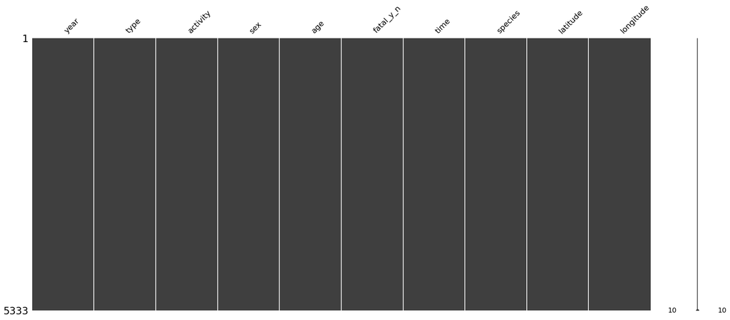

```python
%matplotlib inline
msno.matrix(data)
```

As the above image shows us, now we have clean and none null values in our features. The original length of our data was 6890 and after cleaning is 5333 so we had to ignore 1557 rows.

```python
data.to_csv('shark_attacks_clean.csv')
```

# Data Visualization

Now that we have our cleaned data, we will check the distribution of each feature to get more insight about the data. This task called EDA (exploratory data analysis).

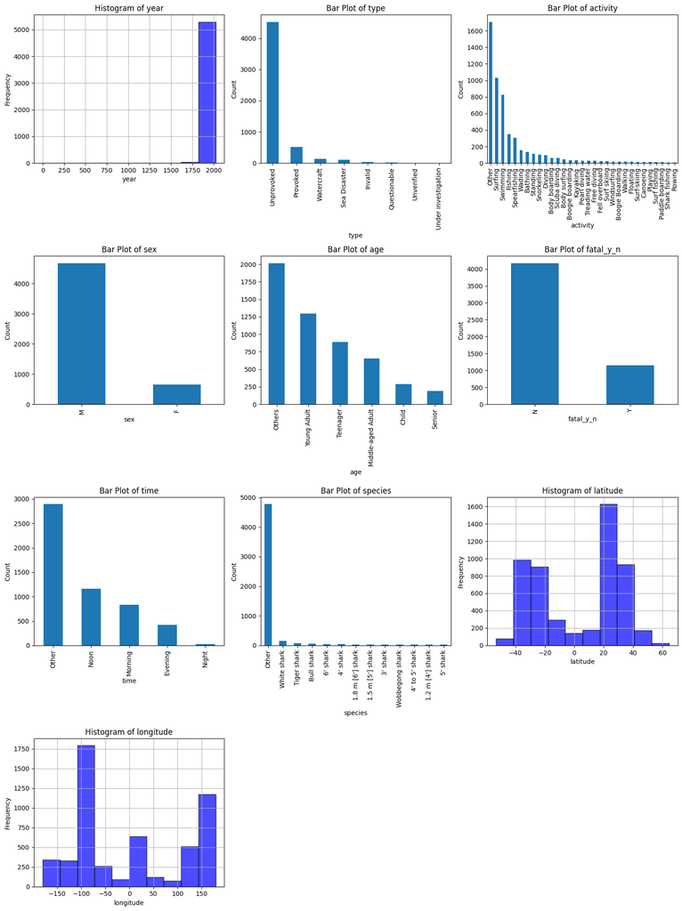

```python
# Plot Each Feature and Target Into One Figure
num_cols = 3
num_features = len(data.columns)
num_rows = math.ceil(num_features / num_cols)

fig, axes = plt.subplots(num_rows, num_cols, figsize=(15, 5 * num_rows))
axes = axes.flatten()

for i, column in enumerate(data.columns):
    ax = axes[i]
    if data[column].dtype == object:
        data[column].value_counts().plot(kind='bar', ax=ax, title=f"Bar Plot of {column}")
        ax.set_ylabel("Count")
    elif data[column].dtype in ['int64', 'float64']:
        data[column].hist(bins=10, alpha=0.7, color='blue', edgecolor='black', ax=ax)
        ax.set_title(f"Histogram of {column}")
        ax.set_xlabel(column)
        ax.set_ylabel("Frequency")

for j in range(len(data.columns), len(axes)):
    fig.delaxes(axes[j])

plt.tight_layout()
plt.show()
```

Some key observations about our data :

1. The histogram of the year shows we have some values for between 0 and above 2000. It does not make sense to have data later than 300 years ago because my assumption is there were no accurate data that could be submitted during those days.
2. We can see based on type feature, most of the attacks were unprovoked.
3. In the activity plot, if we ignore Other value (because of feature imputation for null values), we can observer that the second probable activity for humans who attacked by a shark was surfing.
4. Most of people who attacked by a shark was men.
5. Again we ignore the Other value in all of the plots since it was because of null values, but we can see the most of the attacks happened in the noon and it shows us most of the time people goes into ocean and sea in the noon and the dominant species was white shark.
6. Lastly, as we see into the fatal_y_n plot, we understood that the dataset is imbalanced.

# Feature Engineering

In this part, the main focus is on transforming and reformatting features into a format that machine learning algorithms can read. For example, with the year feature, we can change the *year* column to *years_ago* by subtracting the current year from the year. The other features that are categorical should be encoded, like with one-hot encoding. For latitude and longitude, most machine learning models use Euclidean distance to calculate the distance between two points, which doesn’t make sense for latitude and longitude since the Earth is spherical. To use latitude and longitude, we convert the values into Cartesian coordinates—x, y, z—in 3D space.

```python
data['year'] = 2025 - data['year']
```

```python
def latlon_to_cartesian(lat, lon):
    lat, lon = np.radians(lat), np.radians(lon)
    x = np.cos(lat) * np.cos(lon)
    y = np.cos(lat) * np.sin(lon)
    z = np.sin(lat)
    return x, y, z
data[['x', 'y', 'z']] = data.apply(lambda row: latlon_to_cartesian(row['latitude'], row['longitude']), axis=1, result_type='expand')
data = data.drop(columns = ['latitude', 'longitude'])
```

```python
data.reset_index(drop=True, inplace=True)
```

```python
one_hot_encoder = sklearn.preprocessing.OneHotEncoder(sparse_output=False)
one_hot_categorical_cols = ['type', 'activity', 'sex', 'age', 'time', 'species']
other_columns = ['x','y','z','year','fatal_y_n']
one_hot_encoded_features = one_hot_encoder.fit_transform(data[one_hot_categorical_cols])
data_encoded = pd.concat([pd.DataFrame(one_hot_encoded_features, columns=one_hot_encoder.get_feature_names_out(one_hot_categorical_cols)),
                          data[other_columns]]
                        , axis=1)
```

## Outlier Detection

There are different techniques in machine learning to detect outliers, and a popular one is IQR. In our data, when we look at the year column, we see some entries that are as old as 300 years ago. My assumption is, these are outliers since there wouldn’t be historical data for shark attacks from that long ago. So, we will remove this data from our dataset.

```python
count = (data_encoded['year'] > 300).sum()
print(count)
```

```
10
```

```python
data_encoded = data_encoded[data_encoded['year'] <= 300]
data_encoded.reset_index(drop=True, inplace=True)
data_encoded.info()
```

```
<class 'pandas.core.frame.DataFrame'>
RangeIndex: 5323 entries, 0 to 5322
Data columns (total 70 columns):
 #   Column                    Non-Null Count  Dtype
---  ------                    --------------  -----
 0   type_Invalid              5323 non-null   float64
 1   type_Provoked             5323 non-null   float64
 2   type_Questionable         5323 non-null   float64
 3   type_Sea Disaster         5323 non-null   float64
 4   type_Under investigation  5323 non-null   float64
 5   type_Unprovoked           5323 non-null   float64
 6   type_Unverified           5323 non-null   float64
 7   type_Watercraft           5323 non-null   float64
 8   activity_Bathing          5323 non-null   float64
 9   activity_Body boarding    5323 non-null   float64
```

[output cut: 62 more lines]

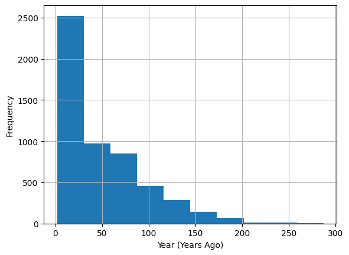

```python
data_encoded['year'].hist()
plt.xlabel('Year (Years Ago)')
plt.ylabel('Frequency')
plt.show()
```

Now we can see that in our data, the year, which shows how many years ago a shark attack happened, indicates that most of them occurred recently, within the last 50 years.

## Correlation Matrix

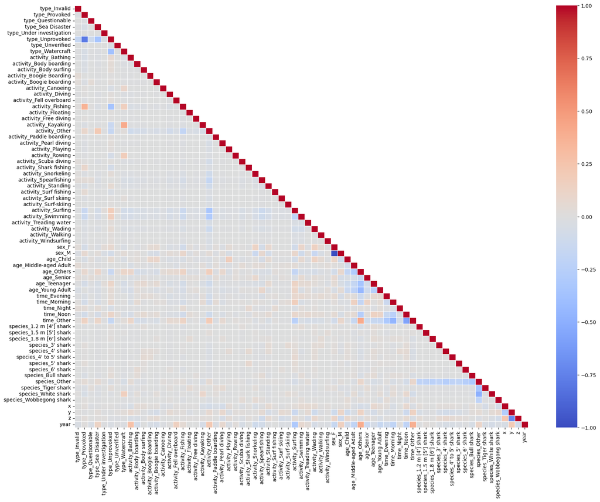

```python
correlation_matrix = data_encoded.drop(columns=['fatal_y_n']).corr()
mask = np.triu(np.ones_like(correlation_matrix, dtype=bool), k=1)
fig, ax = plt.subplots(figsize=(20, 15))
sns.heatmap(correlation_matrix, mask=mask, cmap='coolwarm', annot=False, fmt=".2f", linewidths=0.5)
```

# Model Training

## Split Data

First we change our target column to 1 and 0 values based on their labels.

```python
data_encoded['fatal_y_n'] = data_encoded['fatal_y_n'].map({'Y': 1, 'N': 0})
```

Next we split our dataset into Train and Test. Later we apply k-fold cross validation with hyperparameters tuning for our models. When the best model selected, we test our model with the test dataset.

```python
data_train, data_test = sklearn.model_selection.train_test_split(data_encoded, test_size=0.20, random_state=42)
print(f"Train shape: {data_train.shape}")
print(f"Test shape: {data_test.shape}")
```

[output not shown]

```python
X_train = data_train.drop(columns=['fatal_y_n'])
y_train = data_train['fatal_y_n']

X_test = data_test.drop(columns=['fatal_y_n'])
y_test = data_test['fatal_y_n']
```

## Balancing Data

In this section, I used SMOTE approach which is Synthetic Minority Oversampling Technique that oversample the class that is minor.

```python
smote = imblearn.over_sampling.SMOTE(sampling_strategy='auto', random_state=42)
X_train_resampled, y_train_resampled = smote.fit_resample(X_train, y_train)

print("Before SMOTE:", Counter(y_train))
print("After SMOTE:", Counter(y_train_resampled))

X_train = X_train_resampled
y_train = y_train_resampled
```

[output not shown]

## K-Fold cross validation

Now for selecting a better model and since our dataset size is not big enough, I used k-fold cross validation with 5 number of fold. This method will ensure that our model train on different subset of data. The metric that helps us to select our model in k-fold cross validation and hyperparamater tuning is **f1_weighted** which indicates weighted average of f1 score.

```python
kfold = sklearn.model_selection.KFold(n_splits=5, shuffle=True, random_state=42)
```

## Logistic Regression

This section belongs to applying Logistic Regression classifier on our data. We combine both k-fold cross validation and hyperparameters tuning for the model.

```python
param_grid = {
    'max_iter': [1500, 2000, 2500, 3000],
    'C': [0.1, 0.5, 1, 5, 10]
}

logistic = sklearn.linear_model.LogisticRegression(random_state=42)

grid_search = sklearn.model_selection.GridSearchCV(logistic, param_grid, cv=kfold, scoring='f1_weighted', n_jobs=-1, verbose=1)
grid_search.fit(X_train, y_train)

best_logitstic_regression_model = grid_search.best_estimator_
print("Best Parameters:", grid_search.best_params_)
print("Best Weighted Avg on F1-Score: ", grid_search.best_score_)
```

```
Fitting 5 folds for each of 20 candidates, totalling 100 fits
Best Parameters: {'C': 0.5, 'max_iter': 1500}
Best Weighted Avg on F1-Score:  0.7662193726552413
```

## Naive Baye's

Now we apply Naive Baye's method on our dataset.

```python
param_grid = {
    'var_smoothing': [1e-9, 1e-8, 1e-7, 1e-6, 1e-5]
}

gnb = sklearn.naive_bayes.GaussianNB()

grid_search = sklearn.model_selection.GridSearchCV(gnb, param_grid, cv=kfold, scoring='f1_weighted', n_jobs=-1, verbose=1)
grid_search.fit(X_train, y_train)

best_gnb_model = grid_search.best_estimator_
print("Best Parameters:", grid_search.best_params_)
print("Best Weighted Avg on F1-Score: ", grid_search.best_score_)
```

```
Fitting 5 folds for each of 5 candidates, totalling 25 fits
Best Parameters: {'var_smoothing': 1e-05}
Best Weighted Avg on F1-Score:  0.7126058900305221
```

## SVM

In this part we apply svm classifier with different C and kernels to get our best models for our folds.

```python
param_grid = {
    'C': [0.1, 1, 10, 100],
    'kernel': ['linear', 'rbf', 'poly']
}

svm = sklearn.svm.SVC(random_state=42)

grid_search = sklearn.model_selection.GridSearchCV(svm, param_grid, cv=kfold, scoring='f1_weighted', n_jobs=-1, verbose=1)
grid_search.fit(X_train, y_train)

best_svm_model = grid_search.best_estimator_
print("Best Parameters:", grid_search.best_params_)
print("Best Weighted Avg on F1-Score: ", grid_search.best_score_)
```

```
Fitting 5 folds for each of 12 candidates, totalling 60 fits
Best Parameters: {'C': 10, 'kernel': 'linear'}
Best Weighted Avg on F1-Score:  0.7684538919242936
```

## KNN

Now it is time to apply KNN with different paramaters.

```python
param_grid = {
    'n_neighbors': [3, 5, 10, 15, 20],
    'weights': ['uniform', 'distance'],
    'metric': ['minkowski', 'euclidean', 'manhattan', 'cosine']
}

knn = sklearn.neighbors.KNeighborsClassifier()

grid_search = sklearn.model_selection.GridSearchCV(knn, param_grid, cv=kfold, scoring='f1_weighted', n_jobs=-1, verbose=1)
grid_search.fit(X_train, y_train)

best_knn_model = grid_search.best_estimator_
print("Best Parameters:", grid_search.best_params_)
print("Best Weighted Avg on F1-Score: ", grid_search.best_score_)
```

```
Fitting 5 folds for each of 40 candidates, totalling 200 fits
Best Parameters: {'metric': 'manhattan', 'n_neighbors': 3, 'weights': 'distance'}
Best Weighted Avg on F1-Score:  0.8641933729200547
```

## Decision Tree

This section focus on training decision trees with different hyperparameters

```python
param_grid = {
    'criterion': ['gini', 'entropy'],
    'max_depth': [5, 10, 15, None],
    'min_samples_split': [2, 5, 10],
    'min_samples_leaf': [1, 2, 4]
}

decision_tree = sklearn.tree.DecisionTreeClassifier()

grid_search = sklearn.model_selection.GridSearchCV(decision_tree, param_grid, cv=kfold, scoring='f1_weighted', n_jobs=-1, verbose=1)
grid_search.fit(X_train, y_train)

best_decision_tree_model = grid_search.best_estimator_
print("Best Parameters:", grid_search.best_params_)
print("Best Weighted Avg on F1-Score: ", grid_search.best_score_)
```

```
Fitting 5 folds for each of 72 candidates, totalling 360 fits
Best Parameters: {'criterion': 'gini', 'max_depth': None, 'min_samples_leaf': 2, 'min_samples_split': 2}
Best Weighted Avg on F1-Score:  0.8400229549733671
```

## Bagging (Random Forest)

In this section, we try to fit one of bagging ensemble methods like random forest with different hyperparameters on different fold of dataset.

```python
param_grid = {
    'n_estimators': [20, 30, 500, 100, 200, 500],
    'max_depth': [None, 10, 20, 30],
    'min_samples_split': [2, 5, 10],
    'min_samples_leaf': [1, 2, 4]
}

random_forest = sklearn.ensemble.RandomForestClassifier(random_state=42)

grid_search = sklearn.model_selection.GridSearchCV(random_forest, param_grid, cv=kfold, scoring='f1_weighted', n_jobs=-1, verbose=1)
grid_search.fit(X_train, y_train)

best_random_forest_model = grid_search.best_estimator_
print("Best Parameters:", grid_search.best_params_)
print("Best Weighted Avg on F1-Score: ", grid_search.best_score_)
```

```
Fitting 5 folds for each of 216 candidates, totalling 1080 fits
Best Parameters: {'max_depth': 30, 'min_samples_leaf': 1, 'min_samples_split': 5, 'n_estimators': 500}
Best Weighted Avg on F1-Score:  0.8874867188328199
```

## Boosting

And finally, we trained the data on our last model which is an ensemble method named GradientBoosting.

```python
param_grid = {
    'n_estimators': [50, 100, 200, 300],
    'learning_rate': [0.01, 0.1, 0.2],
    'max_depth': [3, 5, 10],
}

gradient_boosting = sklearn.ensemble.GradientBoostingClassifier(random_state=42)

grid_search = sklearn.model_selection.GridSearchCV(gradient_boosting, param_grid, cv=kfold, scoring='f1_weighted', n_jobs=-1, verbose=1)
grid_search.fit(X_train, y_train)

best_grid_search = grid_search.best_estimator_
print("Best Parameters:", grid_search.best_params_)
print("Best Weighted Avg on F1-Score: ", grid_search.best_score_)
```

```
Fitting 5 folds for each of 36 candidates, totalling 180 fits
Best Parameters: {'learning_rate': 0.2, 'max_depth': 10, 'n_estimators': 200}
Best Weighted Avg on F1-Score:  0.8844951847571234
```

Here is the summary of each best model trained of different fold of the dataset, the metric that I chose for selecting the best model is 'f1_weighted'.

**Logistic Regression: 0.766**

**Naive Baye's: 0.712**

**SVM: 0.768**

**KNN: 0.864**

**Decision Tree: 0.840**

**Random Forest: 0.887**

**Boosting: 0.884**

As we can see into our models ensemble methods works better. Based on the chosen metric, I choose Random Forest model as the best model. In the next part, I will train the RandomForest model with the best paramaters on the train dataset but this time without k-fold cross validation and evaluate the model with the test dataset.

## Final Model

```python
random_forest = sklearn.ensemble.RandomForestClassifier(random_state=42,
                                                        max_depth=30,
                                                        min_samples_leaf=1,
                                                        min_samples_split= 5,
                                                        n_estimators=500)
random_forest.fit(X_train, y_train)
y_pred_random_forest = random_forest.predict(X_test)

report = sklearn.metrics.classification_report(y_test, y_pred_random_forest)
print("Classification Report:\n", report)
```

```
Classification Report:
               precision    recall  f1-score   support

           0       0.87      0.91      0.89       847
           1       0.58      0.49      0.53       220

    accuracy                           0.82      1067
   macro avg       0.73      0.70      0.71      1067
weighted avg       0.81      0.82      0.82      1067
```

The code above shows us that for label 0 we have 87% precision and 91% recall. But when it comes to label 1 both preicsion and recall degraded. One thing that comes into my mind first is this dataset is imbalanced and most of the data belongs to class 0. However, this model has a good performance for label 0. But let's draw our PR curve to check if we can improve these metrics with fine tuning the threshold.

```
Best threshold: 0.35
Max F1-score: 0.60
```

[figure not shown]

```python
y_prob = random_forest.predict_proba(X_test)[:, 1]
precision, recall, thresholds = sklearn.metrics.precision_recall_curve(y_test, y_prob)

valid_thresholds = thresholds[(thresholds >= 0.1) & (thresholds <= 0.9)]
f1_scores = [sklearn.metrics.f1_score(y_test, y_prob >= t) for t in valid_thresholds]

best_threshold = valid_thresholds[np.argmax(f1_scores)]
max_f1_score = np.max(f1_scores)

print(f"Best threshold: {best_threshold:.2f}")
print(f"Max F1-score: {max_f1_score:.2f}")

plt.plot(recall, precision, label="Precision-Recall curve")
plt.scatter(recall[np.argmax(f1_scores)], precision[np.argmax(f1_scores)], color="red", label=f"Best Threshold: {best_threshold:.2f}")
plt.xlabel('Recall')
plt.ylabel('Precision')
plt.title('Precision-Recall Curve')
plt.legend()
plt.show()
```

Now let's calculate the classification report for threshold 0.35 for both labels.

```python
threshold = 0.35
y_pred = (y_prob >= threshold).astype(int)
report = sklearn.metrics.classification_report(y_test, y_pred ,sample_weight=sample_weight)
print("Classification Report:\n", report)
```

```
Classification Report:
               precision    recall  f1-score   support

           0       0.92      0.82      0.87     847.0
           1       0.51      0.72      0.60     220.0

    accuracy                           0.80    1067.0
   macro avg       0.71      0.77      0.73    1067.0
weighted avg       0.83      0.80      0.81    1067.0
```

Again as we can see, with selecting a better threshold, we could maximize the f1-score on label 1, but again the performance of model on the label 0 is far better than label 1. There are different reasons for that, that will be discussed further in Result section. However, we might take a look at weighted avg of f1-score with value of 0.81 since the test class is also imbalanced. the number of data for each class considers for weighted avg score.

Now let's break down the result of above report. This model has precision of 92% and recall of 82% for class label 0 and precision of 51% and recall of 72% for class label 1. This give us insight that this model overally works better for class 0 i.e. if the attack is not fatal. So for example if a shark attacks human and we feed the features into our model, if the predicted result is not fatal we can accurately consider that the attack is not fatal. But on the other hand, if the predicted value is fatal, we have to do more clinical research to be sure if the attack is fatal because with a high chance the model predicted poorly and the attack is not fatal.

Also, this model is not bad at all and it really depends on our needs. If we think in that way, since this model can predict non fatal attacks well, if the first responder check that the attack is not fatal so there is no need to move patient to the hospital. But if the attacks is predicted fatal there might be a chance that after further examination, the prediction was wrong. So basically, it would reduce the loads on hospitals.

```python
with open('random_forest_model.pkl', 'wb') as f:
    pickle.dump(gradient_boosting, f)
```

# Result

To have a better understanding Let’s take a look at the confusion matrix.

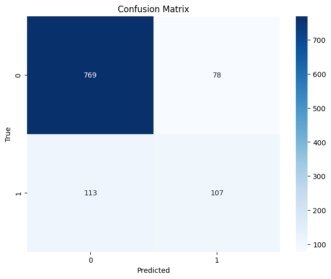

```python
cm = sklearn.metrics.confusion_matrix(y_test, y_pred_random_forest)
plt.figure(figsize=(8, 6))
sns.heatmap(cm, annot=True, fmt='d', cmap='Blues', xticklabels=random_forest.classes_, yticklabels=random_forest.classes_)
plt.xlabel('Predicted')
plt.ylabel('True')
plt.title('Confusion Matrix')
plt.show()
```

Here is the full detail of above image:

TP=107, TN=769, FP=78, FN=113

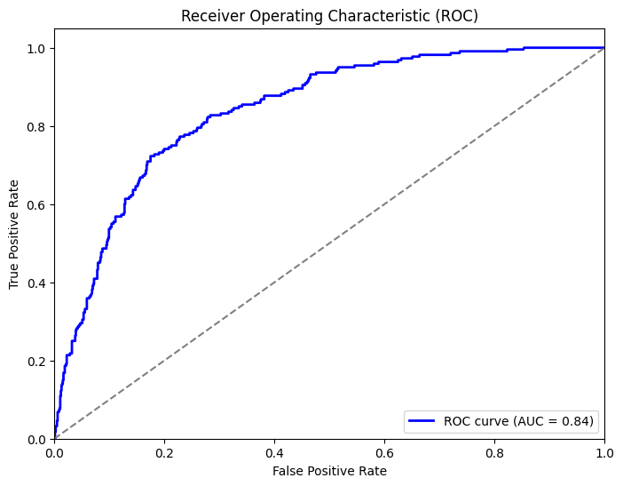

```
AUC: 0.84
```

```python
fpr, tpr, thresholds = sklearn.metrics.roc_curve(y_test, y_prob)
roc_auc = sklearn.metrics.auc(fpr, tpr)

plt.figure(figsize=(8, 6))
plt.plot(fpr, tpr, color='blue', lw=2, label=f'ROC curve (AUC = {roc_auc:.2f})')
plt.plot([0, 1], [0, 1], color='gray', linestyle='--')
plt.xlim([0.0, 1.0])
plt.ylim([0.0, 1.05])
plt.xlabel('False Positive Rate')
plt.ylabel('True Positive Rate')
plt.title('Receiver Operating Characteristic (ROC)')
plt.legend(loc='lower right')
plt.show()

print(f'AUC: {roc_auc:.2f}')
```

# Conclusion

In this notebook, I tried to first clean the Shark Attacks dataset. The dataset was small and very messy. For each column, I used different techniques for cleaning to avoid deleting too many rows, so we could keep more data after cleaning. Once the cleaning phase was done, I visualized the features using plots and applied some feature engineering to make the data better and more readable for machines. Next, I split the data into Train and Test datasets and tried to balance it using the SMOTE approach. Finally, I applied common machine learning methods for a classification task to build a model that can classify whether shark attacks were fatal or not. The results weren’t great because the data itself wasn’t clean or accurate. To get a better model in machine learning, the quality of the data is key. The next step for the future is to collect more real and accurate data on this topic and then apply all the methods mentioned in this notebook again.